# Tips and Tricks

PDAC Meeting

11/19/2019

## Methods

Methods and generics in R allow us to express a generic idea (such as plot, print, summary) and dispatch an associated function, relative to it’s class. For example

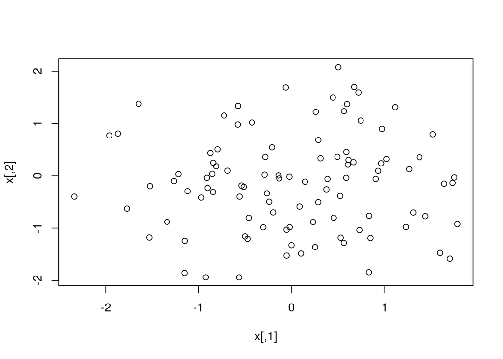

```r
x <- matrix(rnorm(200), ncol = 2)
y <- lm(Sepal.Length ~ Sepal.Width + Petal.Length, data = iris)

plot(x)
```

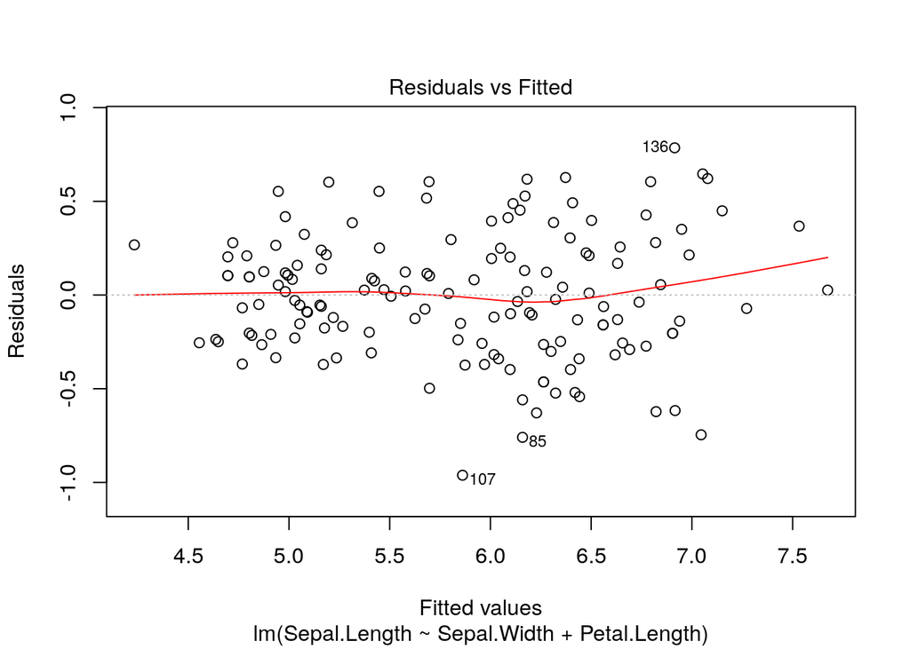

```r
plot(y, which = 1)
```

We can see the methods availabe to us with the `methods` call

```r
class(x); class(y)
```

```
## [1] "matrix"
```

```
## [1] "lm"
```

```r
plot
```

```
## function (x, y, ...)
## UseMethod("plot")
## <bytecode: 0x55a135d33358>
## <environment: namespace:graphics>
```

```r
methods(plot)
```

```
##  [1] plot.acf*           plot.data.frame*    plot.decomposed.ts*
##  [4] plot.default        plot.dendrogram*    plot.density*
##  [7] plot.ecdf           plot.factor*        plot.formula*
## [10] plot.function       plot.hclust*        plot.histogram*
## [13] plot.HoltWinters*   plot.isoreg*        plot.lm*
## [16] plot.medpolish*     plot.mlm*           plot.ppr*
## [19] plot.prcomp*        plot.princomp*      plot.profile.nls*
## [22] plot.raster*        plot.spec*          plot.stepfun
## [25] plot.stl*           plot.table*         plot.ts
## [28] plot.tskernel*      plot.TukeyHSD*
## see '?methods' for accessing help and source code
```

```r
?plot.default
?plot.lm
```

This is implemented in a pretty straightforward manner, and are written of the form `generic.class()` (which also emphasizes why we should use underscores instead of periods for function names)

```r
## The generic, only calls to method
donothing <- function(x) {
  UseMethod("donothing")
}

## In case a particular method isn't found, use default
donothing.default <- function(x) {
  print("this is default, you should usually include this")
}

## Class specific methods
donothing.matrix <- function(x) {
  print("this is a matrix")
}

donothing.data.frame <- function(x) {
  print("maybe consider using data.table instead")
}

donothing.newclass <- function(x) {
  print("helpful if you want to extend previous methods with your own class")
}

z <- list(1:10)
donothing(z)
```

```
## [1] "this is default, you should usually include this"
```

```r
x <- matrix(rnorm(10))
donothing(x)
```

```
## [1] "this is a matrix"
```

```r
y <- as.data.frame(x)
donothing(y)
```

```
## [1] "maybe consider using data.table instead"
```

```r
## Say w 'inherits' from y
w <- structure(y, class = c("newclass", class(y)))
donothing(w)
```

```
## [1] "helpful if you want to extend previous methods with your own class"
```

## .Rprofile and startup

There may be a few things that you wish to do each time you work with R. One of the options available to us is a configuration file known as an [.Rprofile](https://www.r-bloggers.com/fun-with-rprofile-and-customizing-r-startup/). A user can have multiple .Rprofile files, often there is a system wide file, one in a user’s home directory, as well as one in a project directory (which takes precedence if R is loaded from said directory). Generally none of these are generated by default, and if they are, it’s usually the system wide version. Some things to keep in mind

- Ok to load packages automatically if using interactively
- Helpful to source functions used in analysis
- Ok to set some system options, but BE CAREFUL
- Creating a startup environment allows you to load functions and not worry if you clear the environment with (rm(list = ls()))

We will take a look at an example .Rprofile in RStudio, but for those coming back to this document, a few nice things to include (many taken from linked R-Bloggers page)

```r
## Source all R files in a directory
sourceDir <- function(path, trace = FALSE, ...) {
  for(nm in list.files(path, pattern = "\\.[Rr]")) {
    if(trace) cat(nm, ":")
    source(file.path(path, nm), ...)
    if(trace) cat("\n")
  }
}

## This is bad. Why?
options(stringsAsFactors=FALSE)

## This is OK, scientific notation is hard
options(scipen=50)

## Format printing output
options(width=80, digits = 5)

## Especially nice when quitting from command line
q <- function (save="no", ...) {
  quit(save=save, ...)
}

## Not sure why this isn't default, allows autocomplete of library names
utils::rc.settings(ipck=TRUE)

## I don't typically use these, but they are an excellent idea
## This timestamps (with directory) all of the interactive R code you run
.First <- function(){
  if(interactive()){
    library(utils)
    timestamp(,prefix=paste("##------ [",getwd(),"] ",sep=""))
  }
}

## Then when exiting, it saves your (timestamped) interactive
## history into either a system designated file (R_HISTFILE) or
## into a hidden .Rhistory file in your home directory
.Last <- function(){
  if(interactive()){
    hist_file <- Sys.getenv("R_HISTFILE")
    if(hist_file=="") hist_file <- "~/.RHistory"
    savehistory(hist_file)
  }
}

# ## Make new environment for startup functions (won't be erased with (rm()))
# .startup <- new.env()
# .startup$somefunction <- function() do something
# attach(.startup)
# sys.source("startfuns.R", envir = attach(NULL, name = ".startup"))
```

## Be Careful!

There are a few places that can unsuspectingly cause difficulty. This comes from the patchwork nature of R, and as such, it’s good to be aware of some of the places that things can go wrong. First and absolutely foremost (unrelated to being careful, but absolutely essential practice), avoid Magic Numbers at all cost. This means you should never write something like

```r
x <- 1:10

## No
for(i in 1:10) {
  x[i] <- x[i]^2
}
```

What if you have this written 10,000 times in your code and the length of `x` changes? Far better to be explicit in what you want, i.e.,

```r
x <- 1:10

## Better, I guess
for(i in 1:length(x)) {
  x[i] <- x[i]^2
}
```

Even better, when you are working with vector operations, skip the loop altogether. This holds for basically all pointwise vector operations. R is clever enough to know what you want when you use vectorized arithmetic in the presence of scalars as well (using recycling, as we will see below)

```r
x <- rnorm(10)
y <- rnorm(10)
z <- 1

x*y + z*y - exp(x) + x/y
```

```
##  [1] -2.05282 -1.06310  0.49620 -0.88176  0.27282 -0.73947  1.17943  0.28762
##  [9] -0.50503  2.20186
```

```r
# ## !!!
# x*x != t(x) %*% x
```

Now, despite what was said above for illustrative purposes, we can do one better to anticipate unanticipated changes in our code. First, let’s take a moment to familiarize ourselves with a length zero numeric vector. It is a numeric vector of zero length (duh), but this all means that operations on it are maybe not what you expect

```r
x <- numeric(0L)
x
```

```
## numeric(0)
```

```r
x + 10
```

```
## numeric(0)
```

```r
identical(x, 0L)
```

```
## [1] FALSE
```

This can be a particularly sneaky error in our loops

```r
x <- numeric(0L)

## Incorrect
for(i in 1:length(x)) {
  print(i)
}
```

```
## [1] 1
## [1] 0
```

Instead, the function `seq_along` gives us the expected output

```r
## Correct
for(i in seq_along(x)) {
  print(i)
}
```

Ok, one more place where I lied about what to do. We saw above that `x <- numeric(0L)` returns a vector of zero length. Does this generalize to other positive integers?

```r
## Neat!
x <- numeric(5)
x
```

```
## [1] 0 0 0 0 0
```

```r
length(x)
```

```
## [1] 5
```

```r
## Less neat
x <- list(5)
x
```

```
## [[1]]
## [1] 5
```

```r
length(x)
```

```
## [1] 1
```

We can remedy this again by being more explicit about what we want

```r
x <- vector("numeric", length = 5L)
y <- vector("list", length = 5L)
x
```

```
## [1] 0 0 0 0 0
```

```r
y
```

[output not shown]

We do still see a difference here, unfortunately, and that is in what R chooses to initialize each of the vectors with. I think it is good practice to initialize values with something like `NA` to differentiate between a true zero and an element that was never assigned a value. For example, suppose we want to perform a collection of computations that have a non-zero possibility of failing, and in which `0` is also a plausible solution

```r
## Initialized with 0
y <- vector("numeric", length = 1000L)

set.seed(69)
for(i in seq_along(y)) {
  u <- runif(1)
  if(u < 0.8) {
    y[i] <- rbinom(1, 1, 0.75)
  }
}

table(y, useNA = "always")
```

```
## y
##    0    1 <NA>
##  403  597    0
```

```r
## Initialized with NA
y <- NA*vector("numeric", length = 1000L)

set.seed(69)
for(i in seq_along(y)) {
  u <- runif(1)
  if(u < 0.8) {
    y[i] <- rbinom(1, 1, 0.75)
  }
}

table(y, useNA = "always")
```

```
## y
##    0    1 <NA>
##  242  597  161
```

## Don’t be unnecessarily slow

One of the simplest fixes to slow code is to look for places where we are making copies in memory. This happens any time we use `c()`, `rbind()`, or `cbind()`, for example. Better to initialize a vector (or list) of the appropriate size, and then fill in as necessary. This allows R to preallocate the memory it will need rather than making copies as the need arises

```r
library(rbenchmark)

grow_vec <- function(n) {
  x <- c()
  for(i in seq_len(n)) {
    x <- cbind(x, rnorm(1))
  }
}

init_vec <- function(n) {
  x <- vector("numeric", n)
  for(i in seq_len(n)) {
    x[i] <- rnorm(1)
  }
}


benchmark(
  grow_vec(n = 10000),
  init_vec(n = 10000),
  replications = 25
)
```

```
##                  test replications elapsed relative user.self sys.self
## 1 grow_vec(n = 10000)           25   2.669    6.574     2.661    0.008
## 2 init_vec(n = 10000)           25   0.406    1.000     0.397    0.008
##   user.child sys.child
## 1          0         0
## 2          0         0
```

We’ve seen a few examples so far, and most all of them have used dreaded `for` loops, carrying with them accusations of inefficiency and being slow. However, let’s consider the following ways in which we may complicate finding the column means of a matrix

```r
set.seed(69)
x <- matrix(rnorm(100000*100), ncol = 100)

## Using apply
f_apply <- function(x) {
  res <- apply(x, 2, mean)
}

## Loops
f_loop <- function(x) {
  res <- vector("numeric", ncol(x))
  for(i in seq_along(ncol(x))) {
    res[i] <- mean(x[, i])
  }
}

f_loop2 <- function(x) {
  res <- vector("numeric", ncol(x))
  n <- nrow(x)
  for(i in seq_along(ncol(x))) {
    res[i] <- sum(x[, i])/n
  }
}

## And lapply
f_lapply <- function(x) {
  res <- lapply(as.data.frame(x), mean, numeric(1))
  unlist(res, use.names = FALSE)
}

## And colMeans
benchmark(f_apply(x),
          f_loop(x),
          f_loop2(x),
          f_lapply(x),
          colMeans(x),
          replications = 50)
```

```
##          test replications elapsed relative user.self sys.self user.child
## 5 colMeans(x)           50   0.472     23.6     0.472    0.000          0
## 1  f_apply(x)           50   7.816    390.8     6.261    1.555          0
## 4 f_lapply(x)           50   2.698    134.9     2.598    0.100          0
## 2   f_loop(x)           50   0.024      1.2     0.016    0.008          0
## 3  f_loop2(x)           50   0.020      1.0     0.012    0.008          0
##   sys.child
## 5         0
## 1         0
## 4         0
## 2         0
## 3         0
```

```r
apply
```

```
## function (X, MARGIN, FUN, ...)
## {
##     FUN <- match.fun(FUN)
##     dl <- length(dim(X))
##     if (!dl)
##         stop("dim(X) must have a positive length")
##     if (is.object(X))
##         X <- if (dl == 2L)
##             as.matrix(X)
##         else as.array(X)
##     d <- dim(X)
##     dn <- dimnames(X)
##     ds <- seq_len(dl)
##     if (is.character(MARGIN)) {
##         if (is.null(dnn <- names(dn)))
##             stop("'X' must have named dimnames")
##         MARGIN <- match(MARGIN, dnn)
##         if (anyNA(MARGIN))
##             stop("not all elements of 'MARGIN' are names of dimensions")
##     }
##     s.call <- ds[-MARGIN]
##     s.ans <- ds[MARGIN]
##     d.call <- d[-MARGIN]
##     d.ans <- d[MARGIN]
##     dn.call <- dn[-MARGIN]
##     dn.ans <- dn[MARGIN]
##     d2 <- prod(d.ans)
##     if (d2 == 0L) {
##         newX <- array(vector(typeof(X), 1L), dim = c(prod(d.call),
##             1L))
##         ans <- forceAndCall(1, FUN, if (length(d.call) < 2L) newX[,
##             1] else array(newX[, 1L], d.call, dn.call), ...)
##         return(if (is.null(ans)) ans else if (length(d.ans) <
##             2L) ans[1L][-1L] else array(ans, d.ans, dn.ans))
##     }
##     newX <- aperm(X, c(s.call, s.ans))
##     dim(newX) <- c(prod(d.call), d2)
##     ans <- vector("list", d2)
##     if (length(d.call) < 2L) {
##         if (length(dn.call))
```

[output cut: 35 more lines]

```
##         if (is.null(dn.ans))
##             dn.ans <- vector(mode = "list", length(d.ans))
##         dn1 <- list(ans.names)
##         if (length(dn.call) && !is.null(n1 <- names(dn <- dn.call[1])) &&
##             nzchar(n1) && length(ans.names) == length(dn[[1]]))
##             names(dn1) <- n1
##         dn.ans <- c(dn1, dn.ans)
##         array(ans, c(len.a%/%d2, d.ans), if (!is.null(names(dn.ans)) ||
##             !all(vapply(dn.ans, is.null, NA)))
##             dn.ans)
##     }
##     else ans
## }
## <bytecode: 0x55a1373d8558>
## <environment: namespace:base>
```

```r
x <- rpois(n = 500000, lambda = 20)

benchmark(
  lapply(x, function(y) sqrt(y) < 5),
  vapply(x, function(y) (sqrt(y) < 5), logical(1)),
  replications = 25
)
```

```
##                                               test replications elapsed
## 1               lapply(x, function(y) sqrt(y) < 5)           25   5.602
## 2 vapply(x, function(y) (sqrt(y) < 5), logical(1))           25   5.819
##   relative user.self sys.self user.child sys.child
## 1    1.000     5.599    0.004          0         0
## 2    1.039     5.819    0.000          0         0
```

- `vapply` is going to return a numeric vector, rather than a list (which needs to be unlisted)
- `vapply` gives us type-checking, throwing an error when our function fails to return the appropriate output

Each of these are non-trivial benefits of `vapply`, and we verify the saved overhead by giving a more appropriate comparison

```r
## Unlist AND do type-checking
f_lapply2 <- function(x) {
  res <- lapply(x, function(y) {
    tt <- (sqrt(y) > 5)
    ## Type checking
    if(!is.logical(tt) | length(tt) != 1) stop("stop")
  })
  ## Unlisting
  unlist(res, use.names = FALSE)
}

benchmark(
  vapply(x, function(y) sqrt(y) > 5, logical(1)),
  f_lapply2(x),
  replications = 25
)
```

```
##                                             test replications elapsed relative
## 2                                   f_lapply2(x)           25  10.730    1.907
## 1 vapply(x, function(y) sqrt(y) > 5, logical(1))           25   5.627    1.000
##   user.self sys.self user.child sys.child
## 2    10.717    0.007          0         0
## 1     5.627    0.000          0         0
```

We see that functionals do still have their place, both by performing safety checks and formatting output, and by making code more expressive and easier to read. The main take away here is that the performance cost is minor in day to day work, but if you do make use of the `apply` functionals, especially in computationally heavy simulation, it may be worth investigating what can be saved with an explicit `for` loop (with appropriate type checking, of course).

Hinted at above, if we *do* run `lapply` (or any other function that returns a list), and we wish to unlist it, we can see significant performance gains by passing an additional argument to `unlist`

```r
x <- matrix(rnorm(1e6*2), nrow = 2)
res <- lapply(as.data.frame(x), mean)

## We often don't need the names of the listed elements
benchmark(
unlist(res),
unlist(res, use.names = FALSE)
)
```

```
##                             test replications elapsed relative user.self
## 2 unlist(res, use.names = FALSE)          100   5.203    1.000     5.096
## 1                    unlist(res)          100  14.396    2.767    14.346
##   sys.self user.child sys.child
## 2    0.104          0         0
## 1    0.048          0         0
```

One common use of `lapply` is the generation of simulated observations, reading in files, or some other set of operations resulting in a `data.frame`. The `rbindlist` function, from the `data.table` package, gives us an excellent way to speed up the process of generating a single `data.frame` from the list of `data.frames` we start with. As an added bonus, you end up with a `data.table` instead

```r
library(data.table)

datasets <- lapply(1:1000, function(x) {
  dat <- data.frame(ID = rep(x, 15),
                    A = rnorm(15),
                    B = rnorm(15),
                    C = rnorm(15))
})

f_loop <- function(x) {
  res <- data.frame()
  for(i in seq_along(x)) {
    res <- rbind(res, x[[i]])
  }
}

benchmark(
  f_loop(datasets),
  Reduce(rbind, datasets),
  rbindlist(datasets),
  replications = 10
)
```

```
##                      test replications elapsed relative user.self sys.self
## 1        f_loop(datasets)           10   4.540   349.23     4.540        0
## 3     rbindlist(datasets)           10   0.013     1.00     0.013        0
## 2 Reduce(rbind, datasets)           10   5.474   421.08     5.474        0
##   user.child sys.child
## 1          0         0
## 3          0         0
## 2          0         0
```

```r
# ## My typical pattern
# result <- lapply(datasets, function(x) {
#   # do something
# }) %>% rbindlist()
```